# Calculate porpoise encounter rates

Yi Han

2024-06-28

**Email**: yi.han.178@gmail.com  
**Description**: This file  
(1) prepares and cleans the raw data of the porpoise sighting records,  
(2) calculates the moving average of the encounter rates of the porpoise and saves the data frame as `yfp_moving_average_06_17.csv` in folder `data/analysis_outputs/animal_distribution`for step (3) & (4),  
(3) plots the moving average of the encounter rates, corresponding to Figure 2a,  
(4) summarizes the segment-wise porpoise encounter rates and saves the data frame as `segment_wise_porpoise_abundance.csv` in folder `data/analysis_outputs/animal_distribution`.

## 1. Data preparation

**Read and clean the data file of the sighting records of the porpoise.**

```r
yfp <- read.csv("../../data/raw/derived_csv/animal/yfp_sightings_06_17.csv")
yfp <- yfp %>% mutate(., f_year=as.factor(year))
head(yfp, 5)
```

|  | size | DistMark | year | f_year |
| --- | --- | --- | --- | --- |
| 1 | 3 | 580 | 2006 | 2006 |
| 2 | 1 | 498 | 2006 | 2006 |
| 3 | 6 | 497 | 2006 | 2006 |
| 4 | 3 | 424 | 2006 | 2006 |
| 5 | 3 | 370 | 2006 | 2006 |

**Plot porpoise sighting records along the studied river section in 2006 and 2017, corresponding to Figure S1 in the supporting information. The figure depicts the location and size of each sighting record of the porpoises per 1 km river segment along a 1500 km stretch of the studied river section.**

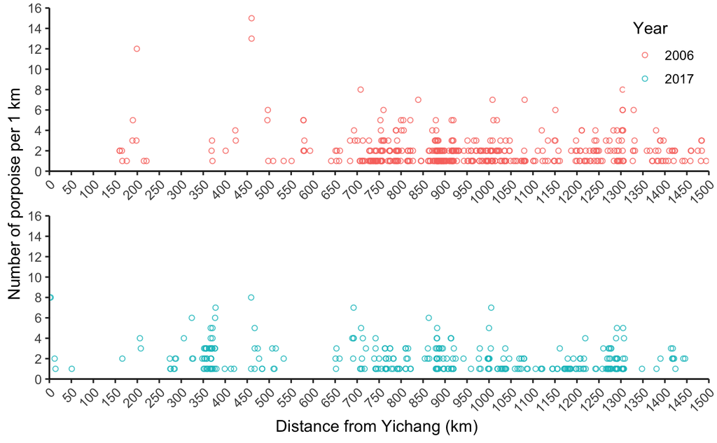

```r
yfp_locations <- ggplot(yfp, aes(x=DistMark, y=size, colour = f_year)) +
    geom_point(shape=21, size=1.5, stroke=0.5, alpha=0.8) +
    scale_x_continuous(expand = c(0, 0), limits = c(0, 1500), breaks=seq(0, 1500, 50)) +
    scale_y_continuous(expand = c(0, 0), limits = c(0, 16), breaks=seq(0, 16, 2)) +
    facet_wrap(~f_year, nrow = 2, scales = "free_x") +
    guides(fill=guide_legend(title="Year"), color=guide_legend(title="Year")) +
    labs (x = "Distance from Yichang (km) ",
          y = "Number of porpoise per 1 km") +
    theme_classic(base_size = 12) +
    theme(axis.text.x = element_text(angle = 45, hjust = 1),
          legend.position = c(.99, .99),
          legend.justification = c("right", "top"),
          legend.box.just = "right",
          strip.text = element_blank(),
          strip.background = element_blank())
yfp_locations
```

```r
# ggsave("../../results/figures/fig_S_1_porpoise_sighting_records.png",
#        yfp_locations, width = 8, height = 6)
```

**Summarize number of individuals sighted per 1 km for each survey.**

```r
list_data <- list()
year_list <- c(2006, 2017)

for (i in 1:2){
    data <- yfp %>%
        dplyr::filter(year==year_list[i]) %>%
        dplyr::group_by(DistMark) %>%
        dplyr::summarise(sum_size = sum(size)/4) %>% # the sighting records were
            # summarized from two survey boats and return trips, thus the number
            # need to be divided by four
        dplyr::ungroup() %>%
        dplyr::mutate(year=year_list[i])
    list_data[[i]] <- data
}

yfp_sum_1km <- bind_rows(list_data[[1]], list_data[[2]]) %>% rename(size = sum_size)

head(yfp_sum_1km, 5)
```

| DistMark | size | year |
| --- | --- | --- |
| 160 | 1.00 | 2006 |
| 165 | 0.50 | 2006 |
| 166 | 0.25 | 2006 |
| 176 | 0.25 | 2006 |
| 189 | 0.75 | 2006 |

## 2. Calculating moving average of the encounter rates of the porpoise

**Create a new data frame storing the results of moving average: df_mov_aver.**

```r
df_mov_aver <- data.frame(
    DistMark = rep(c(0: 1585), 2),
    year = rep(c(2006, 2017), each= 1586),
    f_year = rep(c("2006", "2017"), each = 1586)) %>%
    dplyr::mutate(f_year = as.factor(f_year))
```

**Join the dataframe that summarize number of individuals sighted per 1km to** **the new dataframe by** `DistMark` **and** `year`.

```r
df_mov_aver <- df_mov_aver %>%
    left_join(., yfp_sum_1km, by = c("DistMark", "year")) %>%
    mutate_at(vars(size), ~replace(., is.na(.), 0))
      # the 1-km-long segments with no porpoise sightings will yield NAs
      # replace NAs after the join
```

**Calculate moving average encounter rates using a 50-km window size** **using the** `rollapply` **function from the package** `zoo`.

```r
list_mov_aver <- list()

for (i in 1:2){
   data_mov_aver <- df_mov_aver %>%
     filter(year==year_list[i]) %>%
     mutate(mov_aver = rollapply(size, 50, mean, align=c("center"), fill=NA)) %>%
     filter(DistMark < 1500) %>% # we focus on the 1500 km long river section within [0, 1500)
     mutate(reserve = case_when(DistMark %in% c(209:296, 401: 532, 872:1044, 1088:1147, 1261:1308, 1381:1409) ~ "Y",
                                TRUE ~ "N")) %>%
        # the segments that are identified as reserves
     mutate(reserve_name = case_when(DistMark %in% c(209:296) ~ "shishou",
                                      DistMark %in% c(401: 532) ~ "honghu",
                                      DistMark %in% c(872:1044) ~ "anqing",
                                      DistMark %in% c(1088:1147) ~ "tongling",
                                      DistMark %in% c(1261:1308) ~ "nanjing",
                                      DistMark %in% c(1381:1409) ~ "zhenjiang",
                                      TRUE ~ "non-PAs")) %>%
        # reserve names
     mutate(reserve_without_nj = case_when(DistMark %in% c(209:296, 401: 532, 872:1044, 1088:1147, 1381:1409) ~ "Y",
                                    TRUE ~ "N"))
        # the segments that are identified as reserves before 2006, Nanjing (1261:1308) was excluded
        # as it was established in 2014
     list_mov_aver[[i]] <- data_mov_aver
}
```

**Using a simple average to calculate the encounter rates for points at the end** **of the river section, i.e., [0, 23].**

```r
# We calculate these values manually, and hard code it into above data frame

# In the year 2006, there was no porpoise sighted within [0, 160], therefore, NAs
    # in the interval [0, 23] can be easily replaced by 0s.
list_mov_aver[[1]] <- list_mov_aver[[1]] %>%
      mutate_at(vars(mov_aver), ~replace(., is.na(.), 0))

# In 2017, for the interval [0, 49], the following segments hold porpoises:
    # DistMark = 1, i.e., interval [1, 2), porpoise size = 2,
    # DistMark = 3, i.e., interval [3, 4), porpoise size = 2,
    # DistMark = 12, i.e., interval [12, 13), porpoise size = 0.5,
    # DistMark = 14, i.e., interval [14, 15), porpoise size = 0.25.
# Thus, the simple average of the interval [0, 23] all equal to (2 + 2 + 0.5 + 0.25)/50 = 0.095
list_mov_aver[[2]] <- list_mov_aver[[2]] %>%
      mutate_at(vars(mov_aver), ~replace(., is.na(.), 0.095))
```

**Write the dataframe as a csv file for later analysis.**

```r
data_mov_aver <- bind_rows(list_mov_aver[[1]], list_mov_aver[[2]])
head(data_mov_aver, 5)
```

|  | DistMark | year | f_year | size | mov_aver | reserve | reserve_name | reserve_without_nj |
| --- | --- | --- | --- | --- | --- | --- | --- | --- |
| 1 | 0 | 2006 | 2006 | 0 | 0 | N | non-PAs | N |
| 2 | 1 | 2006 | 2006 | 0 | 0 | N | non-PAs | N |
| 3 | 2 | 2006 | 2006 | 0 | 0 | N | non-PAs | N |
| 4 | 3 | 2006 | 2006 | 0 | 0 | N | non-PAs | N |
| 5 | 4 | 2006 | 2006 | 0 | 0 | N | non-PAs | N |

```r
tail(data_mov_aver, 5)
```

|  | DistMark | year | f_year | size | mov_aver | reserve | reserve_name | reserve_without_nj |
| --- | --- | --- | --- | --- | --- | --- | --- | --- |
| 2996 | 1495 | 2017 | 2017 | 0 | 0.015 | N | non-PAs | N |
| 2997 | 1496 | 2017 | 2017 | 0 | 0.015 | N | non-PAs | N |
| 2998 | 1497 | 2017 | 2017 | 0 | 0.015 | N | non-PAs | N |
| 2999 | 1498 | 2017 | 2017 | 0 | 0.015 | N | non-PAs | N |
| 3000 | 1499 | 2017 | 2017 | 0 | 0.015 | N | non-PAs | N |

```r
str(data_mov_aver)
```

```
'data.frame':   3000 obs. of  8 variables:
 $ DistMark          : int  0 1 2 3 4 5 6 7 8 9 ...
 $ year              : num  2006 2006 2006 2006 2006 ...
 $ f_year            : Factor w/ 2 levels "2006","2017": 1 1 1 1 1 1 1 1 1 1 ...
 $ size              : num  0 0 0 0 0 0 0 0 0 0 ...
 $ mov_aver          : num  0 0 0 0 0 0 0 0 0 0 ...
 $ reserve           : chr  "N" "N" "N" "N" ...
 $ reserve_name      : chr  "non-PAs" "non-PAs" "non-PAs" "non-PAs" ...
 $ reserve_without_nj: chr  "N" "N" "N" "N" ...
```

```r
# write.csv(data_mov_aver,
#           file = "../../data/analysis_outputs/animal_distribution/yfp_moving_average_06_17.csv",
#           row.names = FALSE)
```

## 3. Plot results of moving average

**The following figure corresponds to Figure 2a in the main text.**

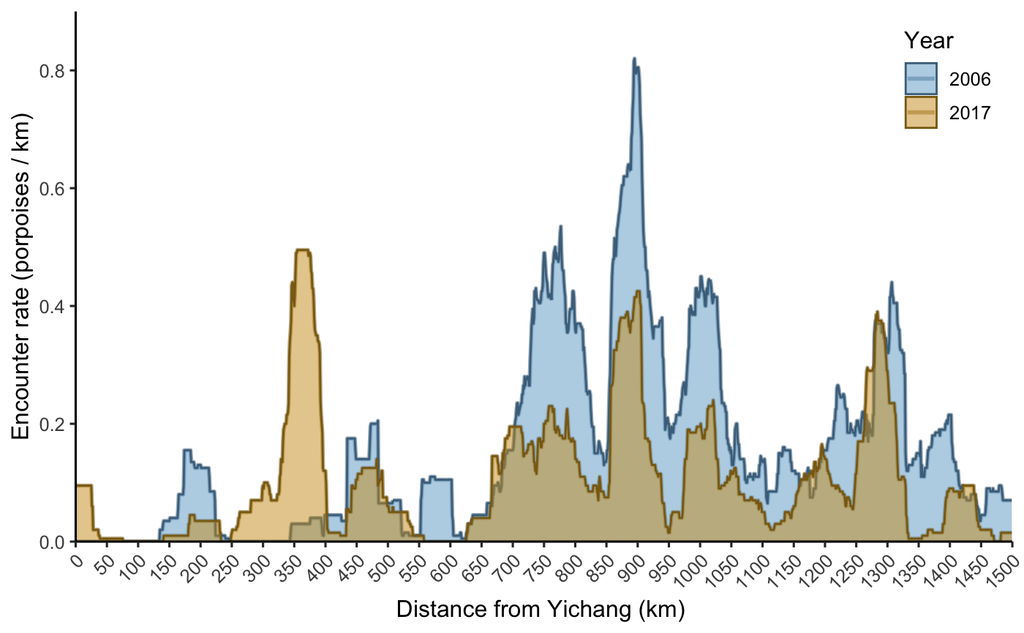

```r
moving_average_porpoise <-
  ggplot(data_mov_aver, aes(x=DistMark, y=mov_aver, colour = f_year)) +
    geom_line(linewidth = 1, alpha = 0.5) +
    geom_area(aes(fill = f_year, group = f_year),
              alpha = 0.5, position = 'identity') + # you want them overlapping,
      #so we need to specify position = 'identity'.
    scale_fill_manual(values = c("skyblue3", "goldenrod3")) +
    scale_color_manual(values = c("skyblue4", "goldenrod4" )) +
    scale_x_continuous(expand = c(0, 0), limits = c(0, 1500), breaks=seq(0, 1500, 50)) +
    scale_y_continuous(expand = c(0, 0), limits = c(0, 0.9), breaks=seq(0, 0.8, 0.2)) +
    labs (x = "Distance from Yichang (km) ",
          y = "Encounter rate (porpoises / km)") +
    guides(fill=guide_legend(title="Year"), color=guide_legend(title="Year")) +
    theme_classic(base_size = 12) +
    theme(axis.text.x = element_text(angle = 45, hjust = 1),
          legend.position = c(.99, .99),
          legend.justification = c("right", "top"),
          legend.box.just = "right")
moving_average_porpoise
```

```r
# ggsave("../../results/figures/fig_2a_moving_avarage_porpoise.png", moving_average_porpoise, width = 8, height = 5)
```

## 4. Prepare segment-wise porpoise abundance for later analysis.

### 4.1 Calculate 10 km-segment-wise porpoise abundance.

```r
# Load the porpoise abundance data calculated for each 1 km segment.
df_mov_aver <- read.csv(file="../../data/analysis_outputs/animal_distribution/yfp_moving_average_06_17.csv")

binwidth = 10

df_seg_mean <- df_mov_aver %>%
    mutate(., groups=cut(x = DistMark,
                         breaks=seq(from=0, to=1500, by = binwidth),
                         dig.lab=5, right = FALSE)) %>%
    group_by(f_year, year, groups, .drop=FALSE) %>%
    summarise(segment_mean = mean(mov_aver)) %>%
    ungroup()
head(df_seg_mean, 5)
```

| f_year | year | groups | segment_mean |
| --- | --- | --- | --- |
| 2006 | 2006 | [0,10) | 0 |
| 2006 | 2006 | [10,20) | 0 |
| 2006 | 2006 | [20,30) | 0 |
| 2006 | 2006 | [30,40) | 0 |
| 2006 | 2006 | [40,50) | 0 |

### 4.2 Assign each bin with the protection status.

Based on the location and range of the six reserves, we hard code the protection status for each segment of each survey.  
- The variable *reserve* specifies whether the segment is located in a reserve in 2017.  
- The variable *reserve_name* specifies the name of the reserve that the segment belongs to, a non-reserve segment is named as ‘non-PAs’.  
- The variable *reserve_without_nj* identifies whether the segment is located in a reserve before 2006, segments belongs to the Nanjing reserve, [1261, 1308] are identified as ‘non-PAs’ as the reserve was established in 2014.

```r
year_list = c(2006, 2017)
data_seg_mean_list = list()

for (i in 1:2){
    data_seg_mean <- df_seg_mean %>%
        filter(year==year_list[i]) %>%
        dplyr:: mutate(group_level = c(1:150)) %>%
        mutate(reserve = case_when(group_level %in% c(22:30, 41:53, 88:104, 110:115, 127:131, 139:141) ~ "Y",
                                   TRUE ~ "N")) %>%
        mutate(reserve_name = case_when(group_level %in% c(22:30) ~ "shishou",
                                         group_level %in% c(41:53) ~ "honghu",
                                         group_level %in% c(88:104) ~ "anqing",
                                         group_level %in% c(110:115) ~ "tongling",
                                         group_level %in% c(127:131) ~ "nanjing",
                                         group_level %in% c(139:141) ~ "zhenjiang",
                                         TRUE ~ "non-PAs")) %>%
        mutate(reserve_without_nj = case_when(group_level %in% c(22:30, 41:53, 88:104, 110:115, 139:141) ~ "Y",
                                       TRUE ~ "N")) %>%
        mutate(reserve = as.factor(reserve),
               reserve_name = as.factor(reserve_name),
               reserve_without_nj = as.factor(reserve_without_nj))
    data_seg_mean_list[[i]] <- data_seg_mean
}
```

### 4.3 Plot data to check if the segmentation was performed correctly.

```r
# with(data_seg_mean_list[[1]], plot(group_level, segment_mean,
#      type="l", lwd=3, xlab="Distance", ylab="Encounter rate"),
#      axis(side = 1, at = seq(0, 1585, by = 100), tcl = -0.2))
#
# with(data_seg_mean_list[[2]], plot(group_level, segment_mean,
#      type="l", lwd=3, xlab="Distance", ylab="Encounter rate"),
#      axis(side = 1, at = seq(0, 1585, by = 100), tcl = -0.2))
```

### 4.4 Add abundance ranks

Ranks and thresholds:  
(1) extremely low abundance: < 0.05 porpoise km-1,  
(2) low abundance: ≥ 0.05 porpoise km-1 and < 0.1 porpoise km-1,  
(3) medium abundance: ≥ 0.1 porpoise km-1 and < 0.2 porpoise km-1,  
(4) high abundance with encounter rates of ≥ 0.20 porpoise km-1.

```r
# Abundance rank data for 2006, when Nanjing is not a reserve
data_06_ranks <- data_seg_mean_list[[1]] %>%
    mutate(., abund_ranks =cut(segment_mean,
                        breaks=c(0, 0.05, 0.1, 0.2, 1),
                        dig.lab=5, right = FALSE)) %>%
    select(groups, f_year, year, abund_ranks, segment_mean, reserve, reserve_without_nj) %>%
    mutate(f_year = as.factor(f_year))

# Abundance rank data for 2017, when Nanjing reserve has been established
data_17_ranks <- data_seg_mean_list[[2]] %>%
    mutate(., abund_ranks =cut(segment_mean,
                               breaks=c(0, 0.05, 0.1, 0.2, 1),
                               dig.lab=5, right = FALSE)) %>%
    select(groups, f_year, year, abund_ranks, segment_mean, reserve, reserve_without_nj) %>%
    mutate(f_year = as.factor(f_year))

# combine above two data frame
data_abund_ranks <- bind_rows(data_06_ranks, data_17_ranks) %>% droplevels()

head(data_abund_ranks, 5)
```

| groups | f_year | year | abund_ranks | segment_mean | reserve | reserve_without_nj |
| --- | --- | --- | --- | --- | --- | --- |
| [0,10) | 2006 | 2006 | [0,0.05) | 0 | N | N |
| [10,20) | 2006 | 2006 | [0,0.05) | 0 | N | N |
| [20,30) | 2006 | 2006 | [0,0.05) | 0 | N | N |
| [30,40) | 2006 | 2006 | [0,0.05) | 0 | N | N |
| [40,50) | 2006 | 2006 | [0,0.05) | 0 | N | N |

```r
tail(data_abund_ranks, 5)
```

| groups | f_year | year | abund_ranks | segment_mean | reserve | reserve_without_nj |
| --- | --- | --- | --- | --- | --- | --- |
| [1450,1460) | 2017 | 2017 | [0,0.05) | 0.020 | N | N |
| [1460,1470) | 2017 | 2017 | [0,0.05) | 0.017 | N | N |
| [1470,1480) | 2017 | 2017 | [0,0.05) | 0.001 | N | N |
| [1480,1490) | 2017 | 2017 | [0,0.05) | 0.012 | N | N |
| [1490,1500) | 2017 | 2017 | [0,0.05) | 0.015 | N | N |

Write the dataframe as a csv file for later analysis.

```r
# write.csv(data_abund_ranks,
#           file = "../../data/analysis_outputs/animal_distribution/segment_wise_porpoise_abundance.csv",
#           row.names = FALSE)
```